# EDA Demo

N Solutions - Voss

2024-12-11

## Data Preparation

### Libraries

```r
#library(tidyverse)
#library(readxl)
#library(readr)
library(tidyr)
library(dplyr)
library(stringr)
library(ggplot2)
library(tibble)
#library(janitor)
library(broom)       # For tidying test results
library(rstatix)     # For assumption tests and effect sizes
library(car)         # For Levene's Test
library(purrr)
library(knitr)
#library(lubridate)
library(kableExtra)
library(ordinal)
```

### Pull in Data, Clean, Transform

Data were combined from several spreadsheets: 1. PeopleBest Assessment Excel Spreadsheet with trait and competency scores. Most recent scores were used for analysis as predictors of outcome variables. 2. SAP Employee file with general information updated monthly. This was used to create a bridge table to link PeopleBest records to Employee data. 3. Turnover Excel Spreadsheet that contains detailed turnover information, including multiple categorical data points. These data were used as an outcome variable to be examined. Turnover was defined as having a Choice value of “Involuntary” and a “Terminated” Term Type. If any records met the criteria for Turnover but was also listed as “Active” in the SAP Employee file, a table is presented with the EE info below. 4. Performance & Potential Excel Spreadsheet with manager ratings.These data were used as an outcome variable to be examined. The most recent rating was used as the outcome.

```r
# Load cleaned data
df_people_gold <-
  readRDS("Data/Gold/df_people_gold_demo.rds")

df_nested <-
  df_people_gold |>
  pivot_longer(invol_group:hi_po,
               names_to = "criterion_name",
               values_to = "criterion_value",
               values_drop_na = TRUE)|>
  mutate(
    criterion_name = if_else(criterion_name == "invol_group",
                             "Turnover",
                             if_else(criterion_name == "hi_perf",
                                     "Performance",
                                     "Potential"))) |>
  nest(-criterion_name)
```

## Descriptive Statistics

### Personality

```r
df_people_gold |>
  select(starts_with("d_")) |>
  rename_with(~ str_remove(., "^d_"), starts_with("d_")) |>
  rename_with(~ str_to_title(str_replace_all(., "_", " "))) |>
  summarize(across(
    everything(),
    list(
      n = ~ sum(!is.na(.)),
      Mean = ~ round(mean(., na.rm = TRUE), 2),
      sd = ~ round(sd(., na.rm = TRUE), 2)
    )
  )) |>
  pivot_longer(
    cols = everything(),
    names_to = "Metric",
    values_to = "Value"
  ) |>
  separate( # Properly split names
    Metric,
    into = c("Variable", "Statistic"),
    sep = "_",
    extra = "merge"
    ) |>
  pivot_wider(
    names_from = "Statistic",
    values_from = "Value"
  ) |>
  kbl(caption = "Summary Table: Sample Size, Mean, and Standard Deviation") |>
  kable_styling(bootstrap_options = c("striped", "hover", "condensed"))
```

Summary Table: Sample Size, Mean, and Standard Deviation

| Variable | n | Mean | sd |
| --- | --- | --- | --- |
| Agreeableness | 226 | 32.40 | 5.73 |
| Channeling Effort | 226 | 32.03 | 6.40 |
| Extraversion | 226 | 34.23 | 5.11 |
| Nature Of Reaction | 226 | 27.97 | 5.67 |
| Originality | 226 | 34.20 | 5.67 |

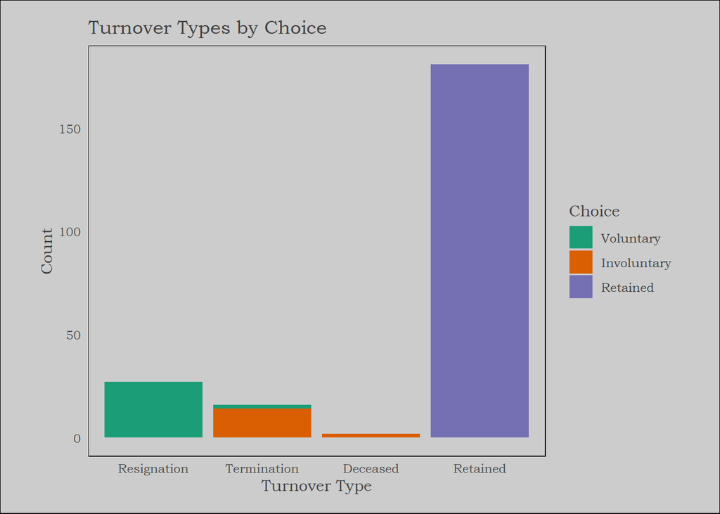

```r
ggplot(df_people_gold, aes(x = term_type, fill = choice)) +
   geom_bar(position = "stack") +
   labs(title = "Turnover Types by Choice",
        x = "Turnover Type",
        y = "Count",
        fill = "Choice") +
   theme_clean() +
  scale_fill_brewer(palette = "Dark2")
```

```r
# Add a column name for rownames
term_table_with_margins <- table(df_people_gold$choice, df_people_gold$term_type, exclude = NULL) |>
  addmargins() |>
  as.data.frame.matrix()|>
  rownames_to_column(var = "Choice") |>
  rename(Total = Sum) |>
  mutate(Choice = if_else(Choice == "Sum", "Total", Choice))

kbl(term_table_with_margins,
    row.names = TRUE,
    caption = "Frequencies: Termination Choice & Type",
    table.attr = 'style="font-family: Bookman, serif;"') |>
  add_header_above(c(" " = 1, "Reason" = ncol(term_table_with_margins))) |>
  kable_styling(bootstrap_options = c("striped", "hover"))|>
  row_spec(nrow(term_table_with_margins), bold = TRUE)|>
  row_spec(nrow(term_table_with_margins) - 1, extra_css = "border-bottom: 1px solid black;")
```

Frequencies: Termination Choice & Type

|  | Reason Choice | Reason Resignation | Reason Termination | Reason Deceased | Reason Retained | Reason Total |
| --- | --- | --- | --- | --- | --- | --- |
| 1 | Voluntary | 27 | 2 | 0 | 0 | 29 |
| 2 | Involuntary | 0 | 14 | 2 | 0 | 16 |
| 3 | Retained | 0 | 0 | 0 | 181 | 181 |
| 4 | Total | 27 | 16 | 2 | 181 | 226 |

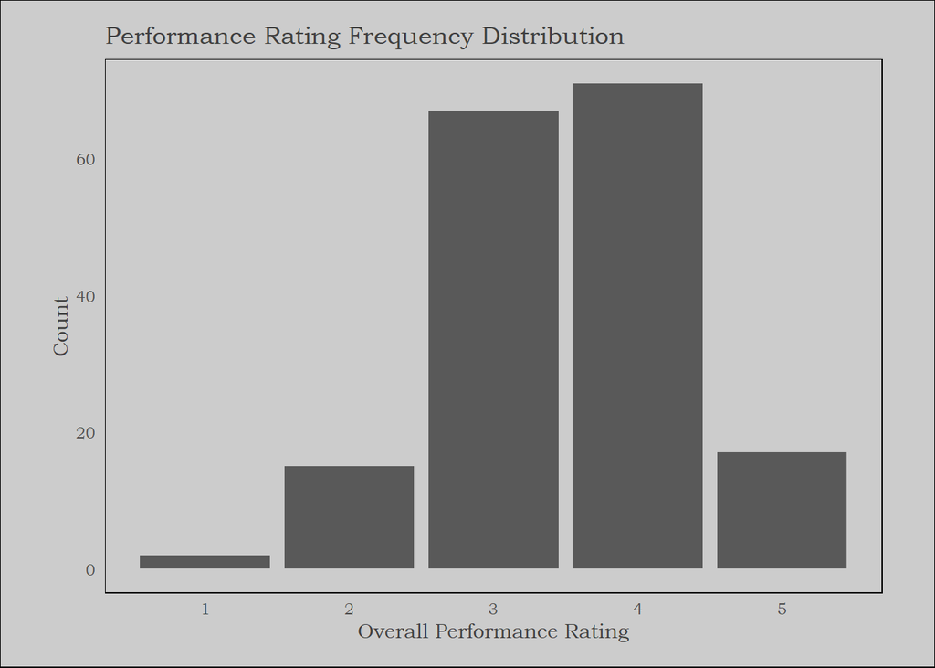

```r
df_performance_potential <-
  df_people_gold |>
  select(overall_performance_rating,
         overall_potential_rating,
         hi_perf,
         hi_po) |>
  filter(!is.na(overall_performance_rating)
         & !is.na(overall_potential_rating))

ggplot(df_performance_potential, aes(x = overall_performance_rating)) +
  geom_bar(position = "stack") +
  labs(x = "Overall Performance Rating",
       y = "Count",
       title = "Performance Rating Frequency Distribution") +
  theme_clean()
```

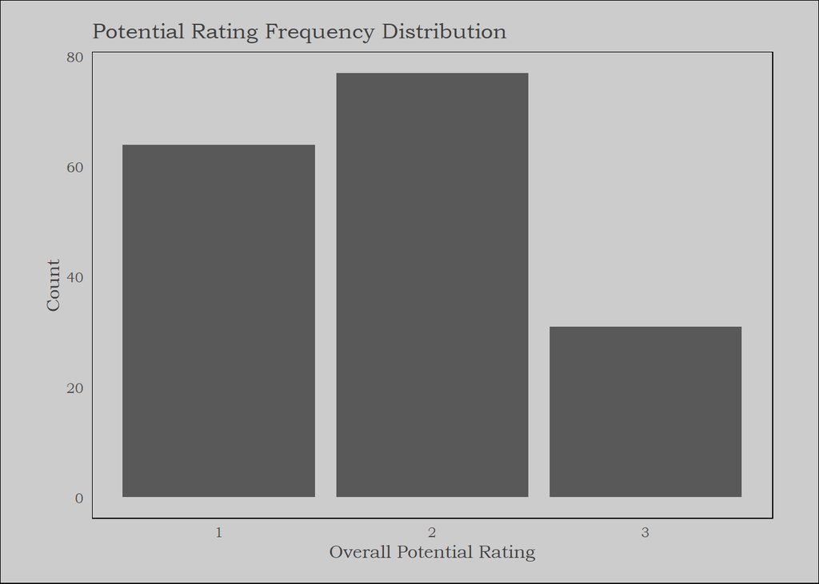

```r
ggplot(df_performance_potential, aes(x = overall_potential_rating)) +
  geom_bar(position = "stack") +
  labs(x = "Overall Potential Rating",
       y = "Count",
       title = "Potential Rating Frequency Distribution") +
  theme_clean()
```

```r
# Add a column name for rownames
perf_pot_table_with_margins <- table(df_performance_potential$hi_perf, df_performance_potential$hi_po, exclude = NULL) |>
  addmargins() |>
  as.data.frame.matrix()|>
  rownames_to_column(var = "Performance") |>
  rename(Low = `0`,
         High = `1`,
         Total = Sum) |>
  mutate(Performance = if_else(Performance == "Sum",
                               "Total",
                               if_else(Performance == 0,
                                       "Low",
                                       "High")))

kbl(perf_pot_table_with_margins,
    #row.names = TRUE,
    caption = "Frequencies: Performance and Potential",
    table.attr = 'style="font-family: Bookman, serif;"') |>
  add_header_above(c(" " = 1, "Potential" = 2, " " = 1)) |>
  kable_styling(bootstrap_options = c("striped", "hover"))|>
  row_spec(nrow(perf_pot_table_with_margins), bold = TRUE)|>
  row_spec(nrow(perf_pot_table_with_margins) - 1, extra_css = "border-bottom: 1px solid black;")
```

Frequencies: Performance and Potential

| Performance | Potential Low | Potential High | Total |
| --- | --- | --- | --- |
| Low | 129 | 26 | 155 |
| High | 12 | 5 | 17 |
| Total | 141 | 31 | 172 |

## Questions

Initial analyses will use a correlation coefficient to evaluate whether there is a relationship between predictors (based on traits) and criteria (i.e., Turnover, Performance, Potential). Correlation coeffients can range between -1 and 1, indicating the strength and direction of the association between two variables. Below is a reference on how to interpret correlation coefficients, provided by Rosenthal (1996).

[figure not shown]

### 1. For involuntary terminations, are there any correlations back to either Job Fit or the common traits these individuals had on their pre-hire assessment?

```r
df_nested_results <- df_nested %>%
  # Use map2 to iterate over both the data and the criterion_name columns in parallel
  mutate(cor_summary = map2(data, criterion_name, ~ {
    # .x is the nested data frame, .y is the criterion_name
    df_data <- .x %>%
      select(empathy:criterion_value)

    # Perform correlation tests for all variables except 'criterion_value'
    res <- map_df(setdiff(names(df_data), "criterion_value"), function(var) {
      test_res <- cor.test(df_data[[var]], df_data[["criterion_value"]])
      tibble(
        Var = var,
        r = round(test_res$estimate, 3),
        p = round(test_res$p.value, 3)
      )
    }) |>
      #filter(p < .11) |>
      slice_max(order_by = abs(r), n = 15)

    # Return a list with the results and the criterion_name
    list(
      results = res,
      criterion_name = .y
    )
  })) %>%
  # Add two new columns:
  # 1) clean_results_df: a cleaned, regular data frame
  # 2) kable_table: a formatted kable table from the cleaned data frame
  mutate(
    clean_results_df = map(cor_summary, ~ {
      .x$results |>
        mutate(Var = str_to_title(str_replace_all(Var, "_", " "))) |>
        arrange(desc(abs(r)))
    }),
    kable_table = map2(cor_summary, clean_results_df, ~ {
      crit_name <- .x$criterion_name
      .y %>%
        kable(format = "html", caption = paste("Criterion:", crit_name)) %>%
        kable_styling(full_width = FALSE, bootstrap_options = c("striped", "hover"))
    })
  )

# Now df_nested_results has:
# - cor_summary: Original list with results and criterion_name
# - clean_results_df: Regular data frame with cleaned variable names, filtered, and sorted results
# - kable_table: HTML kable tables for reporting
# Now df_nested_results$kable_table contains an HTML kable for each record,
# with the criterion_name used in the caption only.
df_nested_results$kable_table
```

[output not shown]

Then, the plot is produced.

```r
df_nested_plots <- df_nested_results %>%
  mutate(plot = map2(clean_results_df, criterion_name, ~ {
    corrs <- .x %>%
      mutate(sig = if_else(p < 0.05, "Significant", "Not Significant"))

    ggplot(corrs, aes(x = reorder(Var, abs(r)), y = r, fill = sig)) +
      geom_col() +
      coord_flip() +
      geom_text(aes(label = round(r, 2), hjust = if_else(r < 0, 1.1, -0.1)), color = "black") +
      scale_fill_manual(values = c("Significant" = "#4CAF50", "Not Significant" = "#BDBDBD")) +
      labs(
        title = paste("Top 15 Correlations with ", .y),
        x = "Variable",
        y = "Correlation (r)",
        fill = "Significance"
      ) +
      theme_clean() +
      theme(
        plot.title = element_text(size = 14, face = "bold"),
        axis.title.y = element_blank(),
        plot.margin = margin(10, 30, 10, 30)
      ) +
      scale_y_continuous(expand = expansion(mult = 0.2))
  }))
```

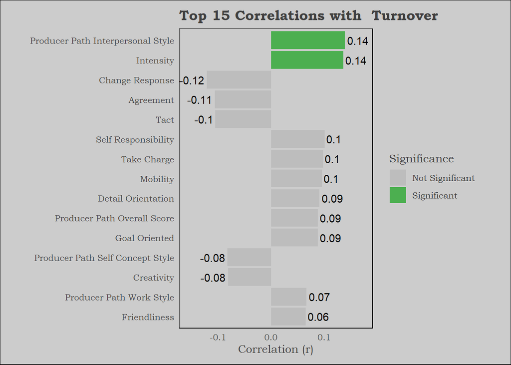

```r
# df_nested_plots now contains a column "plot" with a ggplot for each row.
# You can print them individually:
print(df_nested_plots$plot[[1]])
```

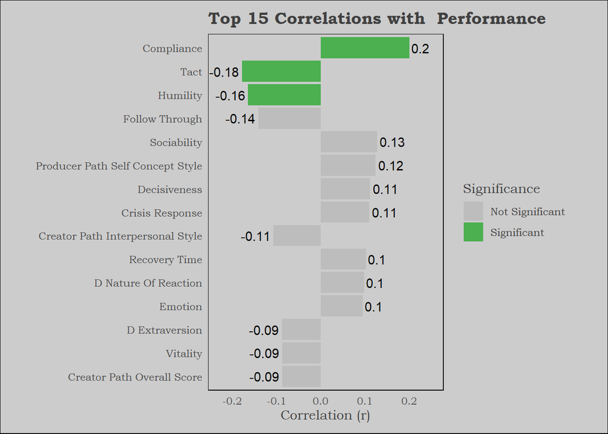

```r
print(df_nested_plots$plot[[2]])
```

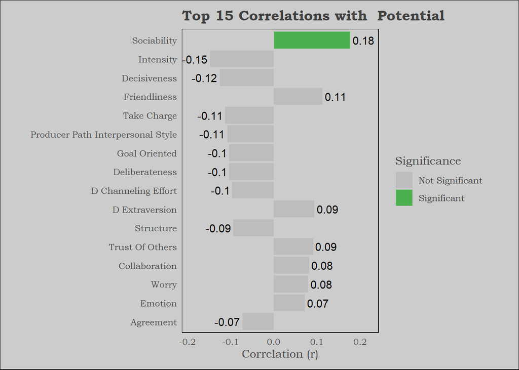

```r
print(df_nested_plots$plot[[3]])
```

## Testing

```r
df_nested_plots <- df_nested_results %>%
  mutate(plot = map2(clean_results_df, criterion_name, ~ {
    corrs <- .x %>%
      mutate(
        category = case_when(
          p < 0.05 & r > 0 ~ "Significant Positive",
          p < 0.05 & r < 0 ~ "Significant Negative",
          TRUE ~ "Not Significant"
        )
      )

    # Order variables by absolute correlation
    corrs <- corrs %>%
      arrange(abs(r)) %>%
      mutate(Var = factor(Var, levels = unique(Var)))

    # Convert factor to numeric for fine-grained vertical spacing
    # We'll place lines at integer y-values
    corrs <- corrs %>%
      mutate(y = as.numeric(Var))

    # Compute start and end points for symmetrical arrows centered at x=0
    # The arrow length = abs(r), so half-length = abs(r)/2
    # Both positive and negative correlations get the same segment,
    # direction indicated by the order of start_x and end_x
    corrs <- corrs %>%
      mutate(
        half_len = abs(r)/2,
        start_x = -half_len,
        end_x = half_len,
        # For positive correlations, arrow points from left to right
        # For negative correlations, arrow points from right to left
        # We'll flip start and end for negative correlations
        start_x = if_else(r < 0, half_len, start_x),
        end_x = if_else(r < 0, -half_len, end_x)
      )

    max_y <- max(corrs$y)
    max_r <- max(abs(corrs$r))

    ggplot(corrs, aes(y = y)) +
      # Draw the arrow lines
      geom_segment(
        aes(x = start_x, xend = end_x, yend = y, color = category),
        arrow = arrow(length = unit(0.2, "cm"), type = "open"),
        linewidth = 2
      ) +
      # Add labels above each arrow line (at y + 0.3 for clarity)
      geom_text(
        aes(x = 0, y = y + 0.6, label = paste0(Var, ": ", round(r, 2))),
        size = 3.5,
        color = "black",
        family = "Bookman"
      ) +
      # Set custom colors for categories
      scale_color_manual(values = c(
        "Significant Positive" = "darkblue",
        "Significant Negative" = "#B86E01",
        "Not Significant" = "darkgrey"
      )) +
      labs(
        title = paste("Top 15 Correlations with", .y),
        x = NULL,
        y = NULL,
        color = "Significance"
      ) +
      theme_clean() +
      theme(
        text = element_text(family = "Bookman"),
        plot.title = element_text(size = 14, face = "bold"),
        axis.text = element_blank(),
        axis.ticks = element_blank(),
        plot.margin = margin(20, 30, 20, 30)
      ) +
      # Add horizontal space so arrows won't be cut off
      #scale_x_continuous(limits = c(-max_r/2 - 0.1, max_r/2 + 0.1), expand = c(0,0)) +
      # Add vertical space to top and bottom
      # We add 1 above and below the range for extra room
      scale_y_continuous(limits = c(0, max_y + 1.5), expand = c(0,0))
  }))
```

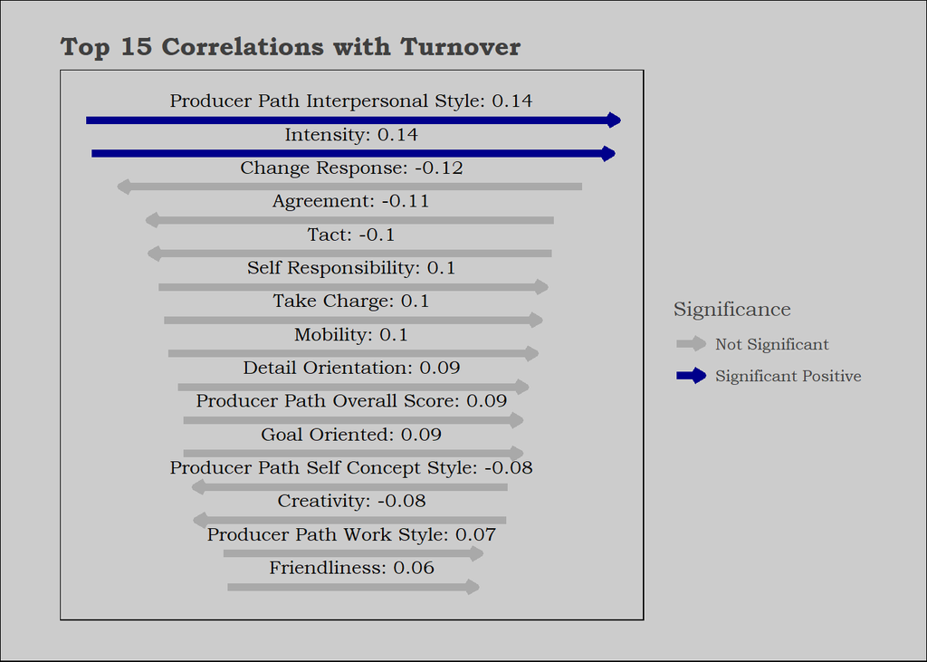

```r
# df_nested_plots now contains a column "plot" with a ggplot for each row.
# You can print them individually:
print(df_nested_plots$plot[[1]])
```

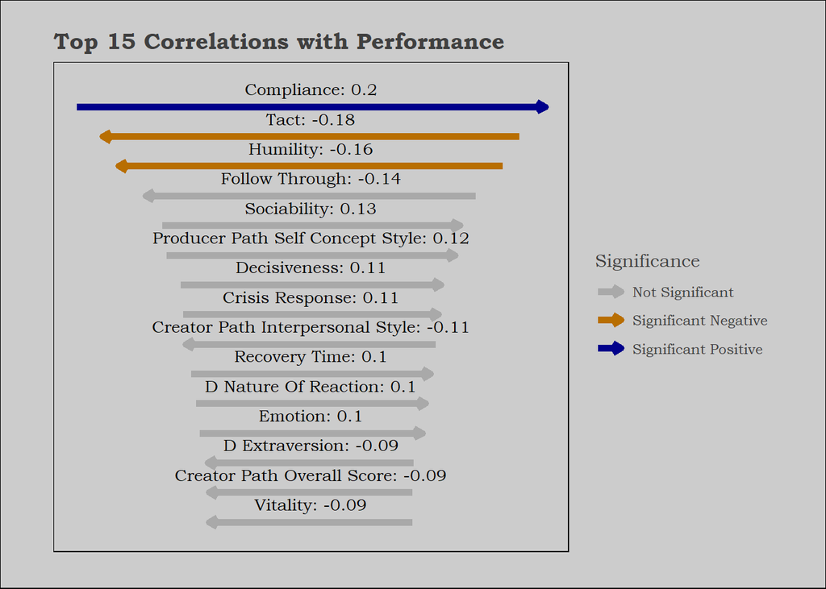

```r
print(df_nested_plots$plot[[2]])
```

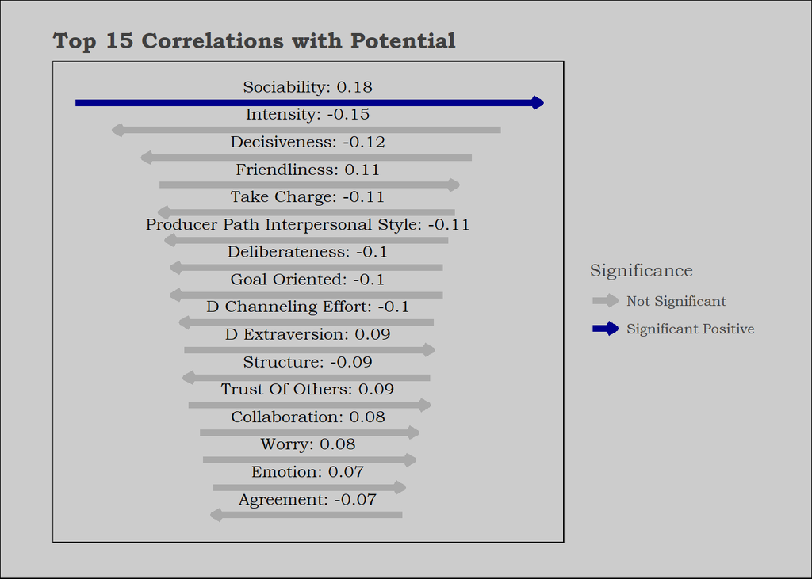

```r
print(df_nested_plots$plot[[3]])
```